# cytoJointR vs COMPASS vs polyICSFlow on public SARS-CoV-2 Spike ICS

```r
# Parameters -------------------------------------------------------------------
RUN_DIR <- Sys.getenv("SARS_RUN_DIR", "runs/2026-11-03_realdata/sarscov2") # run directory, relative to the repo root
PROCESSED_DIR <- "data/processed/sarscov2" # output of 24_prepare-sarscov2.R
POPULATIONS <- strsplit(Sys.getenv("SARS_POPS", "CD4,CD8"), ",")[[1]] # one fit each
P_CUT <- 0.95 # cytoJointR responder rule: P(RMS > epsilon) > 0.95
COMPASS_CUT <- 0.5 # COMPASS responder rule: Response > 0.5
POLY_CUT <- 0 # polyICSFlow responder rule: clipped net sum > 0
COVERAGE_TARGET <- 0.9 # nominal level of the posterior predictive interval
```

```r
suppressPackageStartupMessages({
  library(dplyr)
  library(forcats)
  library(ggplot2)
  library(purrr)
  library(readr)
  library(stringr)
  library(tidyr)
})
theme_set(theme_bw(base_size = 8))
set.seed(1) # jitter only
run_path <- \(...) file.path(here::here(RUN_DIR), ...)
read_pop <- \(f, sub = "") {
  set_names(POPULATIONS) |>
    map(\(p) read_tsv(run_path(p, sub, f), show_col_types = FALSE, col_types = cols(donor_id = "c"))) |>
    list_rbind(names_to = "population")
}
read_proc <- \(f) read_tsv(file.path(here::here(PROCESSED_DIR), f), show_col_types = FALSE)
# One palette keyed by method label; an unknown label fails.
METHOD_COLOURS <- c(
  m1dm = "#D55E00",
  m1 = "#E69F00",
  C0 = "#CC79A7",
  COMPASS = "#0072B2",
  polyICSFlow_clipped = "#009E73",
  polyICSFlow_unclipped = "#999999"
)
as_method <- \(x) {
  stopifnot("unknown method label" = all(x %in% names(METHOD_COLOURS)))
  fct(x, levels = names(METHOD_COLOURS))
}
VISITS <- c("E01", "E02", "E03")
scores <- read_pop("scores.tsv")
visit_change <- read_pop("visit_change.tsv")
compass <- read_pop("compass.tsv")
compass_groups <- read_pop("compass_groups.tsv")
poly <- read_pop("donor_scores.tsv", "polyicsflow")
diagnostics <- read_pop("diagnostics.tsv")
phi_draws <- read_pop("phi_draws.tsv")
loo_table <- read_pop("loo.tsv")
loo_compare <- read_pop("loo_compare.tsv")
loo_pointwise <- read_pop("loo_pointwise.tsv")
ppc <- read_pop("ppc.tsv")
samples <- read_pop("samples.tsv")
runtime <- bind_rows(
  read_pop("runtime.tsv"),
  read_pop("runtime.tsv", "polyicsflow")
)

# One row per method, population, stimulation, donor and visit: magnitude and the conventional responder call.
cj_rms <- scores |>
  filter(score == "RMS", is.na(marker), eps_set == "main") |>
  transmute(population, method = model, stimulation, donor_id, visit, magnitude = estimate, responder = p_positive > P_CUT)
calls <- bind_rows(
  cj_rms,
  compass |>
    transmute(population, method = "COMPASS", stimulation, donor_id, visit, magnitude = Response, responder = Response > COMPASS_CUT),
  poly |>
    pivot_longer(c(clipped, unclipped), names_to = "variant", values_to = "magnitude") |>
    transmute(
      population,
      method = paste0("polyICSFlow_", variant),
      stimulation,
      donor_id,
      visit,
      magnitude,
      responder = magnitude > POLY_CUT
    )
) |>
  mutate(method = as_method(method), visit = fct(visit, levels = VISITS))
```

## Data checks

The two workbooks match their Zenodo md5, every sample is a complete 16-pattern partition of its parent count, and every Spike and PHA sample has one DMSO control at the same donor and visit.

```r
knitr::kable(read_proc("checksums.tsv"), caption = "Downloads against the Zenodo md5")
```

Downloads against the Zenodo md5

| file | size | md5_zenodo | md5_local | match |
| --- | --- | --- | --- | --- |
| CD8_ICS_Boolean_Data.xlsx | 37897 | da0fd5e8ebee2194e6aae54cd2ed86e1 | da0fd5e8ebee2194e6aae54cd2ed86e1 | TRUE |
| CD4_ICS_Boolean_Data.xlsx | 41246 | 975e31de20dd715a15e02062e4e2b312 | 975e31de20dd715a15e02062e4e2b312 | TRUE |

```r
knitr::kable(
  read_proc("data_checks.tsv") |> pivot_wider(names_from = population, values_from = value),
  caption = "Completeness and pairing (unpaired samples removed: see n_unpaired)"
)
```

Completeness and pairing (unpaired samples removed: see n_unpaired)

| check | group | CD4 | CD8 |
| --- | --- | --- | --- |
| n_samples | completeness | 105 | 105 |
| n_not_16_patterns | completeness | 0 | 0 |
| n_na_or_negative | completeness | 0 | 0 |
| min_N | completeness | 2235 | 398 |
| n_stimulated | pairing | 70 | 70 |
| n_dmso | pairing | 35 | 35 |
| n_unpaired | pairing | 0 | 0 |

```r
cat(readLines(file.path(here::here(PROCESSED_DIR), "citation.txt")), sep = "\n")
```

```
Data: Ford ES, Mayer-Blackwell K, Jing L, Laing KJ, Burrow CJ, Koelle DM (2023). CD4+ and CD8+ T cell responses
  to peptides covering SARS-CoV-2 Spike in response to mRNA vaccination in persons recovered from SARS-CoV-2
  infection. Zenodo, doi:10.5281/zenodo.8088178 (CC BY 4.0), published 2023-06-27.
Paper (same first author, group and ICS design; E01 n=7, E02 n=14, E03 n=14 as in the record): Ford ES et al.
  Repeated mRNA vaccination sequentially boosts SARS-CoV-2-specific CD8 T cells in persons with previous
  COVID-19. Nat Immunol 25(1):166-177 (2024), doi:10.1038/s41590-023-01692-x, PMID 38057617. The Zenodo record
  carries no related identifier; the link rests on authors, design and sample sizes.
Visits (paper): E01 before vaccine dose 1; E02 about 19.5 days after dose 1; E03 about 24 days after dose 2.
```

## PHA positive control

PHA is a positive control, so every donor and visit should respond, and each bar is the fraction that each method calls at its conventional rule.

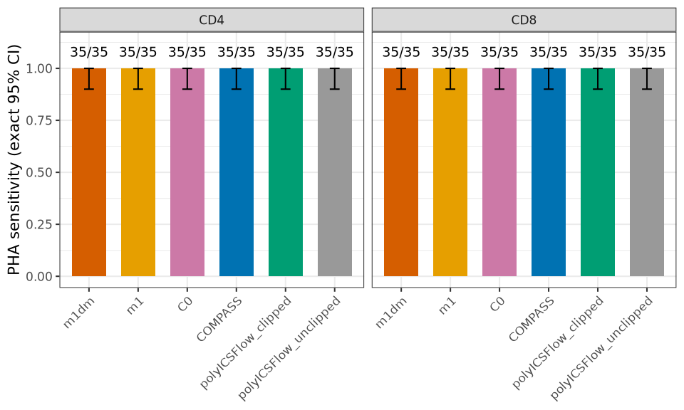

```r
pha <- calls |>
  filter(stimulation == "PHA") |>
  summarise(n = n(), n_responder = sum(responder), .by = c(population, method)) |>
  mutate(
    sensitivity = n_responder / n,
    lower = map2_dbl(n_responder, n, \(k, n) binom.test(k, n)$conf.int[1]),
    upper = map2_dbl(n_responder, n, \(k, n) binom.test(k, n)$conf.int[2])
  )
ggplot(pha, aes(method, sensitivity, fill = method)) +
  geom_col(width = 0.7) +
  geom_errorbar(aes(ymin = lower, ymax = upper), width = 0.2) +
  geom_text(aes(label = paste0(n_responder, "/", n), y = 1.08), size = 2.5) +
  facet_wrap(vars(population)) +
  scale_fill_manual(values = METHOD_COLOURS) +
  scale_y_continuous(limits = c(0, 1.12), breaks = seq(0, 1, 0.25)) +
  labs(x = NULL, y = "PHA sensitivity (exact 95% CI)") +
  theme(axis.text.x = element_text(angle = 45, hjust = 1), legend.position = "none")
```

```r
knitr::kable(pha |> arrange(population, method), digits = 3)
```

| population | method | n | n_responder | sensitivity | lower | upper |
| --- | --- | --- | --- | --- | --- | --- |
| CD4 | m1dm | 35 | 35 | 1 | 0.9 | 1 |
| CD4 | m1 | 35 | 35 | 1 | 0.9 | 1 |
| CD4 | C0 | 35 | 35 | 1 | 0.9 | 1 |
| CD4 | COMPASS | 35 | 35 | 1 | 0.9 | 1 |
| CD4 | polyICSFlow_clipped | 35 | 35 | 1 | 0.9 | 1 |
| CD4 | polyICSFlow_unclipped | 35 | 35 | 1 | 0.9 | 1 |
| CD8 | m1dm | 35 | 35 | 1 | 0.9 | 1 |
| CD8 | m1 | 35 | 35 | 1 | 0.9 | 1 |
| CD8 | C0 | 35 | 35 | 1 | 0.9 | 1 |
| CD8 | COMPASS | 35 | 35 | 1 | 0.9 | 1 |
| CD8 | polyICSFlow_clipped | 35 | 35 | 1 | 0.9 | 1 |
| CD8 | polyICSFlow_unclipped | 35 | 35 | 1 | 0.9 | 1 |

## Spike responders

Each point is one donor-visit; the table gives the fraction each method calls a Spike responder at its conventional rule, and polyICSFlow clipped is positive for almost any sample by construction.

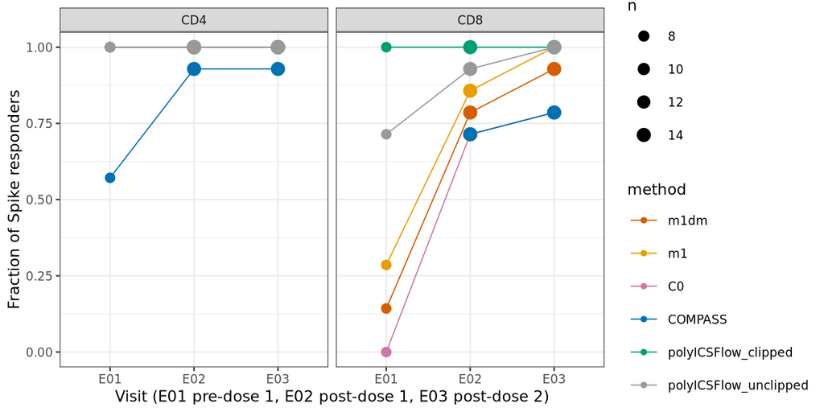

```r
spike <- calls |> filter(stimulation == "Spike")
spike_rate <- spike |>
  summarise(n = n(), fraction = mean(responder), .by = c(population, visit, method))
ggplot(spike_rate, aes(visit, fraction, colour = method, group = method)) +
  geom_line(linewidth = 0.3) +
  geom_point(aes(size = n)) +
  facet_wrap(vars(population)) +
  scale_colour_manual(values = METHOD_COLOURS) +
  scale_size_area(max_size = 3) +
  scale_y_continuous(limits = c(0, 1)) +
  labs(x = "Visit (E01 pre-dose 1, E02 post-dose 1, E03 post-dose 2)", y = "Fraction of Spike responders")
```

```r
knitr::kable(
  spike |>
    summarise(n = n(), fraction = mean(responder), .by = c(population, method)) |>
    arrange(population, method),
  digits = 3
)
```

| population | method | n | fraction |
| --- | --- | --- | --- |
| CD4 | m1dm | 35 | 1.000 |
| CD4 | m1 | 35 | 1.000 |
| CD4 | C0 | 35 | 1.000 |
| CD4 | COMPASS | 35 | 0.857 |
| CD4 | polyICSFlow_clipped | 35 | 1.000 |
| CD4 | polyICSFlow_unclipped | 35 | 1.000 |
| CD8 | m1dm | 35 | 0.714 |
| CD8 | m1 | 35 | 0.800 |
| CD8 | C0 | 35 | 0.600 |
| CD8 | COMPASS | 28 | 0.750 |
| CD8 | polyICSFlow_clipped | 35 | 1.000 |
| CD8 | polyICSFlow_unclipped | 35 | 0.914 |

The epsilon of 1e-4 is one cell in 10 000 as in the benchmark, but a CD8 parent can have only 398 cells, so the table repeats the cytoJointR call with epsilon ten times larger.

```r
scores |>
  filter(score == "RMS", is.na(marker), stimulation == "Spike") |>
  summarise(
    n = n(),
    fraction_responder = mean(p_positive > P_CUT),
    .by = c(population, model, eps_set)
  ) |>
  arrange(population, model, eps_set) |>
  knitr::kable(digits = 3, caption = "Spike responders by epsilon set (main = 1e-4, sens = 1e-3)")
```

Spike responders by epsilon set (main = 1e-4, sens = 1e-3)

| population | model | eps_set | n | fraction_responder |
| --- | --- | --- | --- | --- |
| CD4 | C0 | main | 35 | 1.000 |
| CD4 | C0 | sens | 35 | 0.943 |
| CD4 | m1 | main | 35 | 1.000 |
| CD4 | m1 | sens | 35 | 0.914 |
| CD4 | m1dm | main | 35 | 1.000 |
| CD4 | m1dm | sens | 35 | 0.943 |
| CD8 | C0 | main | 35 | 0.600 |
| CD8 | C0 | sens | 35 | 0.514 |
| CD8 | m1 | main | 35 | 0.800 |
| CD8 | m1 | sens | 35 | 0.600 |
| CD8 | m1dm | main | 35 | 0.714 |
| CD8 | m1dm | sens | 35 | 0.543 |

## Spike magnitude

The m1dm posterior mean RMS (percent of the parent population, net of DMSO) is shown per donor-visit with the median as a bar.

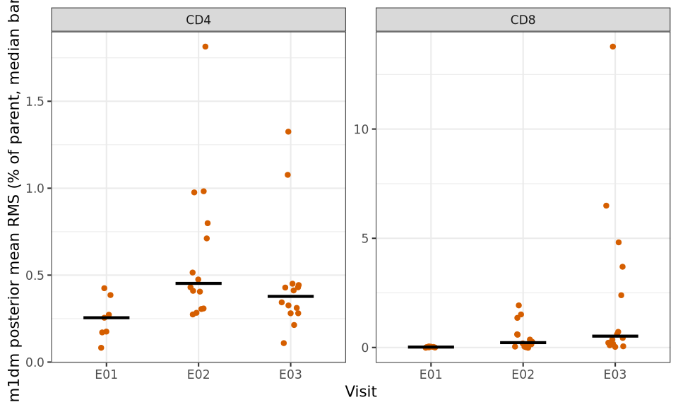

```r
mag <- spike |> filter(method == "m1dm") |> mutate(percent = 100 * magnitude)
ggplot(mag, aes(visit, percent)) +
  geom_point(position = position_jitter(width = 0.1, seed = 1), colour = METHOD_COLOURS[["m1dm"]], size = 1) +
  stat_summary(fun = median, geom = "crossbar", width = 0.5, linewidth = 0.3) +
  facet_wrap(vars(population), scales = "free_y") +
  labs(x = "Visit", y = "m1dm posterior mean RMS (% of parent, median bar)")
```

```r
knitr::kable(
  mag |> summarise(n = n(), median = median(percent), q25 = quantile(percent, 0.25), q75 = quantile(percent, 0.75), .by = c(population, visit)),
  digits = 3
)
```

| population | visit | n | median | q25 | q75 |
| --- | --- | --- | --- | --- | --- |
| CD4 | E02 | 14 | 0.453 | 0.332 | 0.777 |
| CD4 | E03 | 14 | 0.378 | 0.288 | 0.440 |
| CD4 | E01 | 7 | 0.255 | 0.173 | 0.329 |
| CD8 | E02 | 14 | 0.221 | 0.040 | 0.598 |
| CD8 | E03 | 14 | 0.519 | 0.177 | 3.370 |
| CD8 | E01 | 7 | 0.018 | 0.001 | 0.030 |

## Method agreement

Each point is one Spike donor-visit; the plot compares m1dm with the other methods on within-population ranks, and the table gives the Spearman correlation.

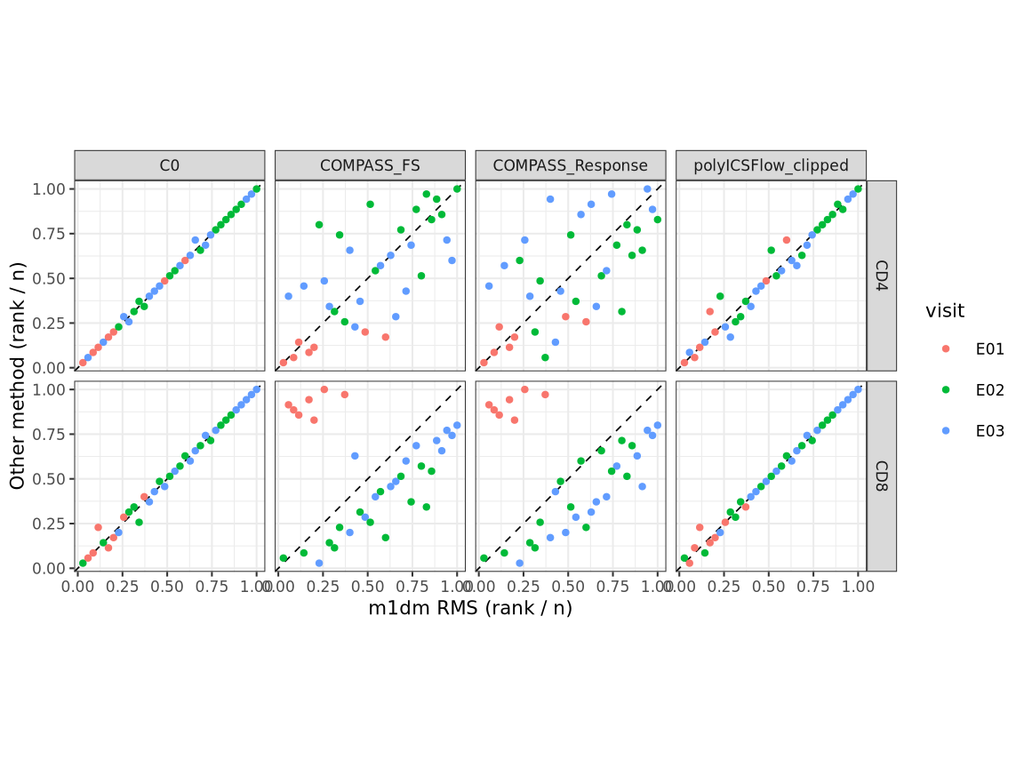

```r
compass_fs <- compass |> filter(stimulation == "Spike") |> transmute(population, donor_id, visit, COMPASS_FS = FS)
wide <- spike |>
  select(population, donor_id, visit, method, magnitude) |>
  pivot_wider(names_from = method, values_from = magnitude) |>
  left_join(compass_fs, join_by(population, donor_id, visit), relationship = "one-to-one") |>
  rename(COMPASS_Response = COMPASS)
AGREE_COLS <- c("m1dm", "m1", "C0", "COMPASS_Response", "COMPASS_FS", "polyICSFlow_clipped", "polyICSFlow_unclipped")
spearman <- wide |>
  group_by(population) |>
  group_modify(\(d, key) {
    cor(d[AGREE_COLS], method = "spearman", use = "pairwise.complete.obs") |> as_tibble(rownames = "a") |> pivot_longer(-a, names_to = "b", values_to = "rho")
  }) |>
  ungroup()
ranks <- wide |>
  mutate(across(all_of(AGREE_COLS), \(v) rank(v) / n()), .by = population) |>
  pivot_longer(c("C0", "COMPASS_Response", "COMPASS_FS", "polyICSFlow_clipped"), names_to = "other", values_to = "rank_other")
ggplot(ranks, aes(m1dm, rank_other, colour = visit)) +
  geom_abline(linetype = 2, linewidth = 0.3) +
  geom_point(size = 1) +
  facet_grid(population ~ other) +
  coord_equal() +
  labs(x = "m1dm RMS (rank / n)", y = "Other method (rank / n)")
```

```r
knitr::kable(
  spearman |> filter(a == "m1dm", b != "m1dm") |> pivot_wider(names_from = population, values_from = rho),
  digits = 2,
  caption = "Spearman correlation with m1dm, Spike donor-visits (repeated visits of a donor are not independent)"
)
```

Spearman correlation with m1dm, Spike donor-visits (repeated visits of a donor are not independent)

| a | b | CD4 | CD8 |
| --- | --- | --- | --- |
| m1dm | m1 | 0.72 | 0.96 |
| m1dm | C0 | 1.00 | 0.99 |
| m1dm | COMPASS_Response | 0.61 | 0.88 |
| m1dm | COMPASS_FS | 0.68 | 0.87 |
| m1dm | polyICSFlow_clipped | 0.98 | 1.00 |
| m1dm | polyICSFlow_unclipped | 0.99 | 1.00 |

## Visit change

Visit change is the per-draw difference in net RMS between visits (the paper defines E01 as before dose 1, E02 as after dose 1 and E03 as after dose 2), shown per donor with the equal-donor average of the observed donors.

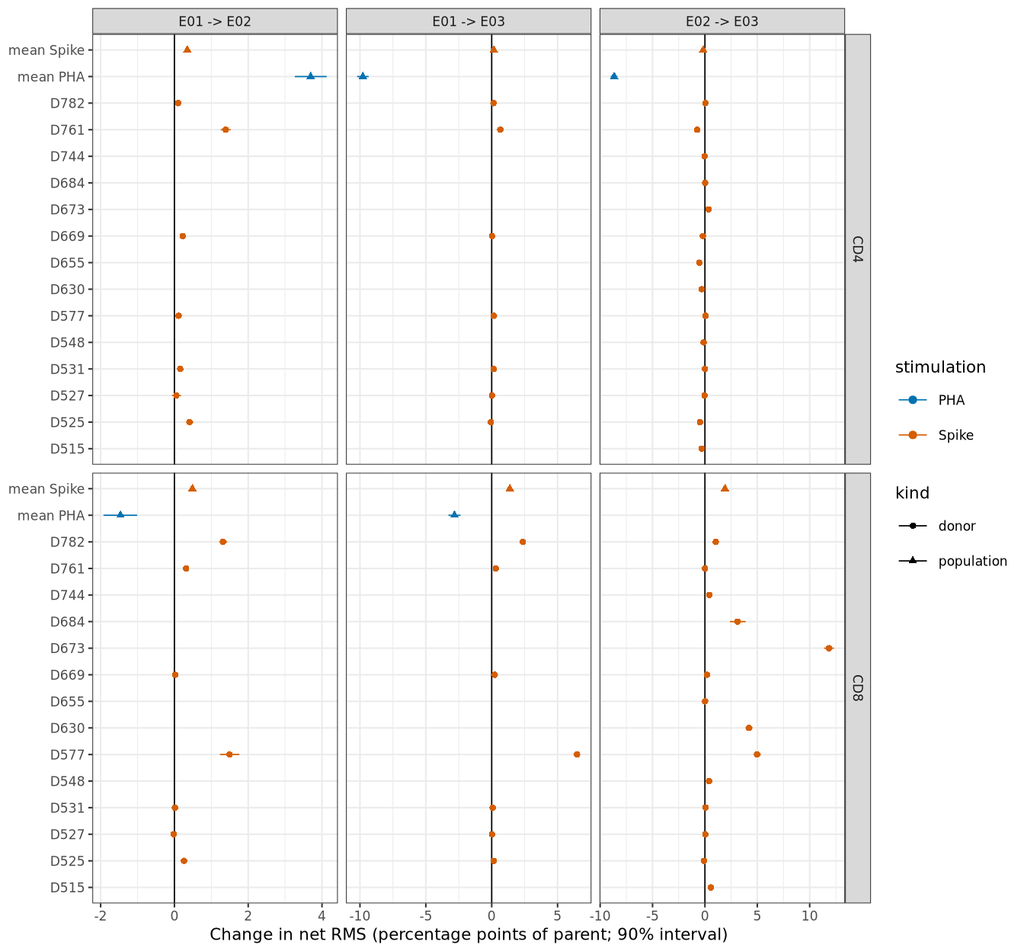

```r
vc <- visit_change |>
  filter(score == "RMS", is.na(marker)) |>
  mutate(pair = paste(from, "->", to), across(c(estimate, lower, upper), \(v) 100 * v))
vc_plot <- bind_rows(
  vc |> filter(grain == "donor", stimulation == "Spike", status == "ok") |> mutate(row = donor_id, kind = "donor"),
  vc |> filter(grain == "population", status == "ok") |> mutate(row = paste("mean", stimulation), kind = "population")
)
ggplot(vc_plot, aes(estimate, row, colour = stimulation, shape = kind)) +
  geom_vline(xintercept = 0, linewidth = 0.3) +
  geom_pointrange(aes(xmin = lower, xmax = upper), linewidth = 0.3, size = 0.25) +
  facet_grid(population ~ pair, scales = "free", space = "free_y") +
  scale_colour_manual(values = c(Spike = "#D55E00", PHA = "#0072B2")) +
  labs(x = "Change in net RMS (percentage points of parent; 90% interval)", y = NULL)
```

```r
knitr::kable(
  vc |> filter(grain == "population") |> select(population, stimulation, pair, n_donors, estimate, lower, upper, p_positive, p_negative),
  digits = 3,
  caption = "Population averages in percentage points; n_donors counts donors with both visits"
)
```

Population averages in percentage points; n_donors counts donors with both visits

| population | stimulation | pair | n_donors | estimate | lower | upper | p_positive | p_negative |
| --- | --- | --- | --- | --- | --- | --- | --- | --- |
| CD4 | Spike | E01 -> E02 | 7 | 0.350 | 0.314 | 0.385 | 1 | 0 |
| CD4 | PHA | E01 -> E02 | 7 | 3.693 | 3.262 | 4.127 | 1 | 0 |
| CD4 | Spike | E01 -> E03 | 7 | 0.159 | 0.123 | 0.194 | 1 | 0 |
| CD4 | PHA | E01 -> E03 | 7 | -9.780 | -10.216 | -9.338 | 0 | 1 |
| CD4 | Spike | E02 -> E03 | 14 | -0.161 | -0.191 | -0.131 | 0 | 1 |
| CD4 | PHA | E02 -> E03 | 14 | -8.664 | -8.991 | -8.347 | 0 | 1 |
| CD8 | Spike | E01 -> E02 | 7 | 0.487 | 0.442 | 0.533 | 1 | 0 |
| CD8 | PHA | E01 -> E02 | 7 | -1.462 | -1.923 | -1.009 | 0 | 1 |
| CD8 | Spike | E01 -> E03 | 7 | 1.377 | 1.329 | 1.426 | 1 | 0 |
| CD8 | PHA | E01 -> E03 | 7 | -2.828 | -3.284 | -2.366 | 0 | 1 |
| CD8 | Spike | E02 -> E03 | 14 | 1.914 | 1.839 | 1.993 | 1 | 0 |
| CD8 | PHA | E02 -> E03 | 14 | -1.045 | -1.416 | -0.665 | 0 | 1 |

## Model criticism: phi

The m1dm overdispersion phi is the Dirichlet-multinomial concentration, so small phi means counts vary more than a multinomial allows.

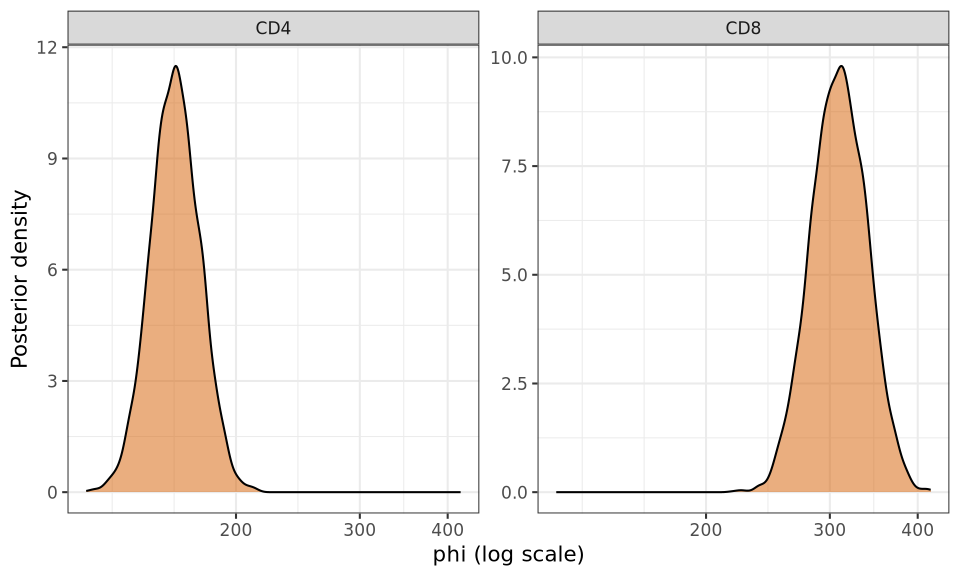

```r
ggplot(phi_draws, aes(phi)) +
  geom_density(fill = METHOD_COLOURS[["m1dm"]], alpha = 0.5) +
  facet_wrap(vars(population), scales = "free_y") +
  scale_x_log10() +
  labs(x = "phi (log scale)", y = "Posterior density")
```

```r
knitr::kable(diagnostics, digits = 3, caption = "Sampler diagnostics and phi summary (90% interval)")
```

Sampler diagnostics and phi summary (90% interval)

| population | model | max_rhat | min_ess_bulk | min_ess_tail | n_divergent | n_max_treedepth | min_ebfmi | phi_mean | phi_q5 | phi_q95 | phi_rhat |
| --- | --- | --- | --- | --- | --- | --- | --- | --- | --- | --- | --- |
| CD4 | m1dm | 1.017 | 444.445 | 934.998 | 0 | 0 | 0.790 | 164.397 | 143.686 | 186.803 | 1.003 |
| CD4 | m1 | 1.007 | 1002.478 | 1534.965 | 48 | 2849 | 0.776 | NA | NA | NA | NA |
| CD8 | m1dm | 1.008 | 562.980 | 1437.079 | 0 | 0 | 0.837 | 310.189 | 265.799 | 357.900 | 1.001 |
| CD8 | m1 | 1.004 | 1055.721 | 1790.617 | 4 | 1160 | 0.789 | NA | NA | NA | NA |

## Model criticism: LOO

```r
knitr::kable(loo_table, digits = 1)
```

| population | model | elpd_loo | se_elpd_loo | p_loo | n_pareto_k_gt_0.7 |
| --- | --- | --- | --- | --- | --- |
| CD4 | m1dm | -6570.5 | 213.6 | 101.8 | 23 |
| CD4 | m1 | -23223.0 | 3534.6 | 1962.4 | 83 |
| CD8 | m1dm | -3696.3 | 219.7 | 100.6 | 34 |
| CD8 | m1 | -7253.1 | 740.4 | 822.2 | 68 |

```r
knitr::kable(loo_compare, digits = 1, caption = "Differences relative to the better model")
```

Differences relative to the better model

| population | model | elpd_diff | se_diff |
| --- | --- | --- | --- |
| CD4 | m1dm | 0.0 | 0.0 |
| CD4 | m1 | -16652.5 | 3389.9 |
| CD8 | m1dm | 0.0 | 0.0 |
| CD8 | m1 | -3556.7 | 557.2 |

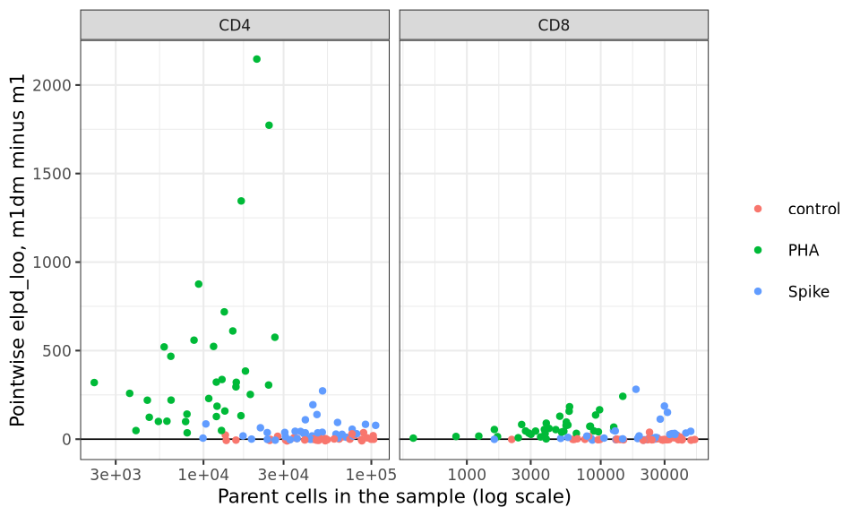

```r
loo_diff <- loo_pointwise |>
  select(population, model, sample_id, elpd) |>
  pivot_wider(names_from = model, values_from = elpd) |>
  left_join(samples, join_by(population, sample_id), relationship = "one-to-one") |>
  mutate(diff = m1dm - m1)
ggplot(loo_diff, aes(N, diff, colour = condition)) +
  geom_hline(yintercept = 0, linewidth = 0.3) +
  geom_point(size = 1) +
  facet_wrap(vars(population), scales = "free_x") +
  scale_x_log10() +
  labs(x = "Parent cells in the sample (log scale)", y = "Pointwise elpd_loo, m1dm minus m1", colour = NULL)
```

```r
loo_pointwise |>
  summarise(n_k_above_0.7 = sum(pareto_k > 0.7), max_k = max(pareto_k), .by = c(population, model)) |>
  knitr::kable(digits = 2, caption = "Pareto k of the pointwise PSIS fits")
```

Pareto k of the pointwise PSIS fits

| population | model | n_k_above_0.7 | max_k |
| --- | --- | --- | --- |
| CD4 | m1dm | 23 | 1.26 |
| CD4 | m1 | 83 | 7.22 |
| CD8 | m1dm | 34 | 1.04 |
| CD8 | m1 | 68 | 4.29 |

## Model criticism: posterior predictive check

Each point compares a sample’s observed count with the 90% interval of 400 replicated counts, for cells positive for any marker, cells in patterns with three or four positive markers, and cells positive for all four.

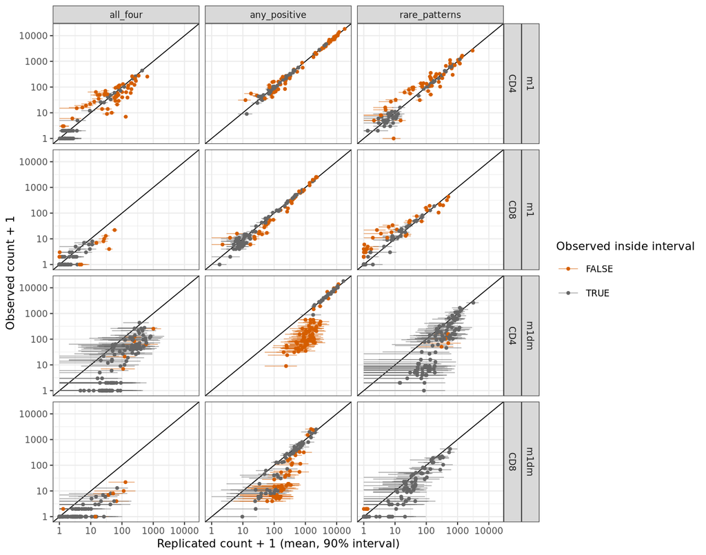

```r
ppc <- ppc |>
  mutate(inside = observed >= rep_lower & observed <= rep_upper, extreme = mid_p < 0.05 | mid_p > 0.95)
ggplot(ppc, aes(rep_mean + 1, observed + 1, colour = inside)) +
  geom_abline(linewidth = 0.3) +
  geom_linerange(aes(xmin = rep_lower + 1, xmax = rep_upper + 1), linewidth = 0.25, alpha = 0.6) +
  geom_point(size = 0.8) +
  facet_grid(model + population ~ statistic) +
  scale_x_log10() +
  scale_y_log10() +
  scale_colour_manual(values = c(`TRUE` = "grey40", `FALSE` = "#D55E00")) +
  labs(x = "Replicated count + 1 (mean, 90% interval)", y = "Observed count + 1", colour = "Observed inside interval")
```

```r
knitr::kable(
  ppc |>
    summarise(coverage = mean(inside), frac_extreme_midp = mean(extreme), .by = c(model, population, statistic)) |>
    arrange(statistic, population, model),
  digits = 3,
  caption = "Coverage of the 90% interval (nominal 0.9) and fraction of samples with mid-p below 0.05 or above 0.95 (nominal 0.1)"
)
```

Coverage of the 90% interval (nominal 0.9) and fraction of samples with mid-p below 0.05 or above 0.95 (nominal 0.1)

| model | population | statistic | coverage | frac_extreme_midp |
| --- | --- | --- | --- | --- |
| m1 | CD4 | all_four | 0.467 | 0.543 |
| m1dm | CD4 | all_four | 0.943 | 0.048 |
| m1 | CD8 | all_four | 0.895 | 0.124 |
| m1dm | CD8 | all_four | 0.933 | 0.067 |
| m1 | CD4 | any_positive | 0.438 | 0.581 |
| m1dm | CD4 | any_positive | 0.267 | 0.724 |
| m1 | CD8 | any_positive | 0.638 | 0.371 |
| m1dm | CD8 | any_positive | 0.552 | 0.486 |
| m1 | CD4 | rare_patterns | 0.486 | 0.533 |
| m1dm | CD4 | rare_patterns | 0.962 | 0.038 |
| m1 | CD8 | rare_patterns | 0.638 | 0.362 |
| m1dm | CD8 | rare_patterns | 0.943 | 0.057 |

The same check by condition shows where the misfit sits: the table gives the median ratio of observed to replicated any-positive count and the share of samples whose observed count falls below the interval.

```r
ppc |>
  filter(statistic == "any_positive") |>
  left_join(samples, join_by(population, sample_id), relationship = "many-to-one") |>
  summarise(
    n = n(),
    median_obs_over_rep = median(observed / pmax(rep_mean, 1)),
    frac_below_interval = mean(observed < rep_lower),
    frac_above_interval = mean(observed > rep_upper),
    .by = c(population, model, condition)
  ) |>
  arrange(population, model, condition) |>
  knitr::kable(digits = 3)
```

| population | model | condition | n | median_obs_over_rep | frac_below_interval | frac_above_interval |
| --- | --- | --- | --- | --- | --- | --- |
| CD4 | m1 | PHA | 35 | 0.987 | 0.457 | 0.314 |
| CD4 | m1 | Spike | 35 | 0.970 | 0.314 | 0.286 |
| CD4 | m1 | control | 35 | 0.890 | 0.200 | 0.114 |
| CD4 | m1dm | PHA | 35 | 0.995 | 0.143 | 0.086 |
| CD4 | m1dm | Spike | 35 | 0.159 | 0.971 | 0.000 |
| CD4 | m1dm | control | 35 | 0.068 | 1.000 | 0.000 |
| CD8 | m1 | PHA | 35 | 0.962 | 0.343 | 0.114 |
| CD8 | m1 | Spike | 35 | 0.863 | 0.429 | 0.114 |
| CD8 | m1 | control | 35 | 0.790 | 0.057 | 0.029 |
| CD8 | m1dm | PHA | 35 | 0.882 | 0.114 | 0.057 |
| CD8 | m1dm | Spike | 35 | 0.166 | 0.686 | 0.029 |
| CD8 | m1dm | control | 35 | 0.072 | 0.457 | 0.000 |

## Runtime

Wall-clock seconds of each method’s main step on 4 CPUs for cytoJointR models and 1 CPU otherwise, with polyICSFlow summed over its three steps.

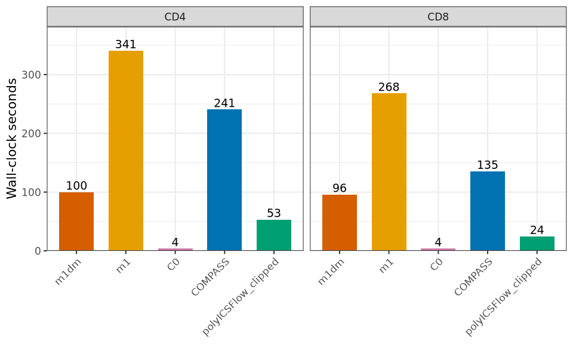

```r
rt <- runtime |>
  filter(step %in% c("fit", "cj_compass", "expand_counts_to_cells", "assignMarkerCombinations", "calcPolyfunctionality")) |>
  mutate(method = if_else(method == "polyICSFlow", "polyICSFlow_clipped", if_else(method == "COMPASS", "COMPASS", method))) |>
  summarise(seconds = sum(seconds), .by = c(population, method)) |>
  mutate(method = as_method(method))
ggplot(rt, aes(method, seconds, fill = method)) +
  geom_col(width = 0.7) +
  geom_text(aes(label = round(seconds)), vjust = -0.3, size = 2.5) +
  facet_wrap(vars(population)) +
  scale_fill_manual(values = METHOD_COLOURS) +
  scale_y_continuous(expand = expansion(mult = c(0, 0.12))) +
  labs(x = NULL, y = "Wall-clock seconds") +
  theme(axis.text.x = element_text(angle = 45, hjust = 1), legend.position = "none")
```